# Group 5 Evaluations

Hello! Please check your evaluations below based on your classmates and instructors. We advise you to come to office hours if specified.

**Below are evaluations from your classmates:**

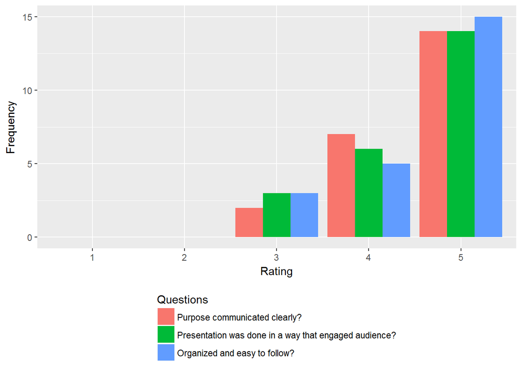

#### What did you like most about the presentation?

- The idea of this project
- The concept seems very powerful and useful for a wide audience.
- Like the idea of seeing how oral health affects heart disease
- I really like the topic. Very relevant.
- Cool presentation, an interesting and important topic which could be used by many people for many different reasons.
- the slide is well made
- Topic/Originality
- They made me realize how important the information is and they convinced me that I’d actually use it
- How they explained info
- clear and feasible data
- Helping people stay healthy
- the enthusiasm and explanation of the products (would be) utility
- It’s extremely unique and bringing up a problem that more people need to know that.
- I never knew this, it will be very interesting to know
- It seems like your project has some really cool real world applications
- I think the idea is relevant and could help raise awareness
- Good source
- Unique Idea
- Very well thought out and thorough
- Clearly outlined the purpose, its audience and the method
- The prezzi! intelligently presented
- health is a very important field
- The prezi presentation was very neat and organized. the topic was also very interesting - it addresses the oral health issue that isn’t very known to public health officials and the public

#### What areas might you suggest for improvement not listed above?

- Where to pull up the data
- None, good luck!
- Having a more organized plan for the overall layout; tools that will be used
- Focusing back on your problem statement. How will you present the information better to people to help them understand causes of death?
- Could be difficult to distinguish the different things that lead to a single cause of death.
- NA
- none
- Definitely divide subgroups by race, age, gender, income, and maybe even countries
- IDK
- none
- Warn more people about oral heart disease!
- statistical methods employed
- Explain what oral health and heart disease are a little more.
- Maybe focus on one audience
- The idea is also very complex and maybe hard to present in a final product
- Not sure
- good
- Perhaps try and be more direct on the data you hope to obtain
- None, this is cool
- Did not state if such tool is available or not.
- be able to show a strong correlation between heart disease and dental care - tricky, as dental care could be coupled to overall health care
- elaborate more since they have a very interesting idea
- none

**Below are notes from your instructors:**

- Causes of death in the US
- Non-chronic that causes death
- Very good project and good motivation. I would be happy to discuss with you to clarify a few things regarding your project. Could you please come to one office hour to discuss it? Thanks!